# Incident management process

# Importing Libraries

```python
import pandas as pd
import numpy as np
import matplotlib.pyplot as plt
%matplotlib inline
import seaborn as sns
sns.set() # setting seaborn default for plots
from sklearn.neighbors import *
from sklearn.linear_model import *
from sklearn.tree import *
from sklearn.naive_bayes import *
from sklearn.ensemble import *
from sklearn.neural_network import *
from sklearn.svm import *
from sklearn.metrics import accuracy_score,precision_score,recall_score,f1_score,roc_auc_score
from prettytable import PrettyTable
from sklearn.preprocessing import LabelEncoder
from sklearn.metrics import mean_absolute_error
from sklearn.model_selection import train_test_split
import pickle

import warnings
warnings.filterwarnings("ignore")
```

# Load Dataset

```python
df =pd.read_csv('incident_event_log.csv')
df
```

|  | number | incident_state | active | reassignment_count | reopen_count | sys_mod_count | made_sla | caller_id | opened_by | opened_at | ... | u_priority_confirmation | notify | problem_id | rfc | vendor | caused_by | closed_code | resolved_by | resolved_at | closed_at |
| --- | --- | --- | --- | --- | --- | --- | --- | --- | --- | --- | --- | --- | --- | --- | --- | --- | --- | --- | --- | --- | --- |
| 0 | INC0000045 | New | True | 0 | 0 | 0 | True | Caller 2403 | Opened by 8 | 29/02/2016 1:16 | ... | False | Do Not Notify | ? | ? | ? | ? | code 5 | Resolved by 149 | 29/02/2016 11:29 | 05/03/2016 12:00 |
| 1 | INC0000045 | Resolved | True | 0 | 0 | 2 | True | Caller 2403 | Opened by 8 | 29/02/2016 1:16 | ... | False | Do Not Notify | ? | ? | ? | ? | code 5 | Resolved by 149 | 29/02/2016 11:29 | 05/03/2016 12:00 |
| 2 | INC0000045 | Resolved | True | 0 | 0 | 3 | True | Caller 2403 | Opened by 8 | 29/02/2016 1:16 | ... | False | Do Not Notify | ? | ? | ? | ? | code 5 | Resolved by 149 | 29/02/2016 11:29 | 05/03/2016 12:00 |
| 3 | INC0000045 | Closed | False | 0 | 0 | 4 | True | Caller 2403 | Opened by 8 | 29/02/2016 1:16 | ... | False | Do Not Notify | ? | ? | ? | ? | code 5 | Resolved by 149 | 29/02/2016 11:29 | 05/03/2016 12:00 |
| 4 | INC0000047 | New | True | 0 | 0 | 0 | True | Caller 2403 | Opened by 397 | 29/02/2016 4:40 | ... | False | Do Not Notify | ? | ? | ? | ? | code 5 | Resolved by 81 | 01/03/2016 9:52 | 06/03/2016 10:00 |
| 5 | INC0000047 | Active | True | 1 | 0 | 1 | True | Caller 2403 | Opened by 397 | 29/02/2016 4:40 | ... | False | Do Not Notify | ? | ? | ? | ? | code 5 | Resolved by 81 | 01/03/2016 9:52 | 06/03/2016 10:00 |
| 6 | INC0000047 | Active | True | 1 | 0 | 2 | True | Caller 2403 | Opened by 397 | 29/02/2016 4:40 | ... | False | Do Not Notify | ? | ? | ? | ? | code 5 | Resolved by 81 | 01/03/2016 9:52 | 06/03/2016 10:00 |
| 7 | INC0000047 | Active | True | 1 | 0 | 3 | True | Caller 2403 | Opened by 397 | 29/02/2016 4:40 | ... | False | Do Not Notify | ? | ? | ? | ? | code 5 | Resolved by 81 | 01/03/2016 9:52 | 06/03/2016 10:00 |
| 8 | INC0000047 | Active | True | 1 | 0 | 4 | True | Caller 2403 | Opened by 397 | 29/02/2016 4:40 | ... | False | Do Not Notify | ? | ? | ? | ? | code 5 | Resolved by 81 | 01/03/2016 9:52 | 06/03/2016 10:00 |
| 9 | INC0000047 | Active | True | 1 | 0 | 5 | True | Caller 2403 | Opened by 397 | 29/02/2016 4:40 | ... | False | Do Not Notify | ? | ? | ? | ? | code 5 | Resolved by 81 | 01/03/2016 9:52 | 06/03/2016 10:00 |
| 10 | INC0000047 | Awaiting User Info | True | 1 | 0 | 6 | True | Caller 2403 | Opened by 397 | 29/02/2016 4:40 | ... | False | Do Not Notify | ? | ? | ? | ? | code 5 | Resolved by 81 | 01/03/2016 9:52 | 06/03/2016 10:00 |
| 11 | INC0000047 | Resolved | True | 1 | 0 | 7 | True | Caller 2403 | Opened by 397 | 29/02/2016 4:40 | ... | False | Do Not Notify | ? | ? | ? | ? | code 5 | Resolved by 81 | 01/03/2016 9:52 | 06/03/2016 10:00 |
| 12 | INC0000047 | Closed | False | 1 | 0 | 8 | True | Caller 2403 | Opened by 397 | 29/02/2016 4:40 | ... | False | Do Not Notify | ? | ? | ? | ? | code 5 | Resolved by 81 | 01/03/2016 9:52 | 06/03/2016 10:00 |
| 13 | INC0000057 | New | True | 0 | 0 | 0 | True | Caller 4416 | Opened by 8 | 29/02/2016 6:10 | ... | False | Do Not Notify | ? | ? | ? | ? | code 10 | Resolved by 5 | 01/03/2016 2:55 | 06/03/2016 3:00 |
| 14 | INC0000057 | New | True | 0 | 0 | 1 | True | Caller 4416 | Opened by 8 | 29/02/2016 6:10 | ... | False | Do Not Notify | ? | ? | ? | ? | code 10 | Resolved by 5 | 01/03/2016 2:55 | 06/03/2016 3:00 |
| 15 | INC0000057 | New | True | 0 | 0 | 2 | True | Caller 4416 | Opened by 8 | 29/02/2016 6:10 | ... | False | Do Not Notify | Problem ID 2 | ? | ? | ? | code 10 | Resolved by 5 | 01/03/2016 2:55 | 06/03/2016 3:00 |
| 16 | INC0000057 | New | True | 0 | 0 | 3 | True | Caller 4416 | Opened by 8 | 29/02/2016 6:10 | ... | False | Do Not Notify | Problem ID 2 | ? | ? | ? | code 10 | Resolved by 5 | 01/03/2016 2:55 | 06/03/2016 3:00 |
| 17 | INC0000057 | New | True | 0 | 0 | 4 | True | Caller 4416 | Opened by 8 | 29/02/2016 6:10 | ... | False | Do Not Notify | Problem ID 2 | ? | ? | ? | code 10 | Resolved by 5 | 01/03/2016 2:55 | 06/03/2016 3:00 |
| 18 | INC0000057 | Resolved | True | 0 | 0 | 5 | True | Caller 4416 | Opened by 8 | 29/02/2016 6:10 | ... | False | Do Not Notify | Problem ID 2 | ? | ? | ? | code 10 | Resolved by 5 | 01/03/2016 2:55 | 06/03/2016 3:00 |
| 19 | INC0000057 | Closed | False | 0 | 0 | 6 | True | Caller 4416 | Opened by 8 | 29/02/2016 6:10 | ... | False | Do Not Notify | Problem ID 2 | ? | ? | ? | code 10 | Resolved by 5 | 01/03/2016 2:55 | 06/03/2016 3:00 |
| 20 | INC0000060 | New | True | 0 | 0 | 0 | True | Caller 4491 | Opened by 180 | 29/02/2016 6:38 | ... | False | Do Not Notify | ? | ? | ? | ? | code 3 | Resolved by 113 | 02/03/2016 12:06 | 07/03/2016 13:00 |
| 21 | INC0000060 | Active | True | 0 | 0 | 1 | True | Caller 4491 | Opened by 180 | 29/02/2016 6:38 | ... | False | Do Not Notify | ? | ? | ? | ? | code 3 | Resolved by 113 | 02/03/2016 12:06 | 07/03/2016 13:00 |
| 22 | INC0000060 | Resolved | True | 0 | 0 | 2 | True | Caller 4491 | Opened by 180 | 29/02/2016 6:38 | ... | False | Do Not Notify | ? | ? | ? | ? | code 3 | Resolved by 113 | 02/03/2016 12:06 | 07/03/2016 13:00 |
| 23 | INC0000060 | Closed | False | 0 | 0 | 3 | True | Caller 4491 | Opened by 180 | 29/02/2016 6:38 | ... | False | Do Not Notify | ? | ? | ? | ? | code 3 | Resolved by 113 | 02/03/2016 12:06 | 07/03/2016 13:00 |
| 24 | INC0000062 | New | True | 0 | 0 | 0 | True | Caller 3765 | Opened by 180 | 29/02/2016 6:58 | ... | False | Do Not Notify | ? | ? | ? | ? | code 7 | Resolved by 62 | 29/02/2016 15:51 | 05/03/2016 16:00 |
| 25 | INC0000062 | New | True | 0 | 0 | 1 | True | Caller 3765 | Opened by 180 | 29/02/2016 6:58 | ... | False | Do Not Notify | ? | ? | ? | ? | code 7 | Resolved by 62 | 29/02/2016 15:51 | 05/03/2016 16:00 |
| 26 | INC0000062 | New | True | 1 | 0 | 2 | True | Caller 3765 | Opened by 180 | 29/02/2016 6:58 | ... | False | Do Not Notify | ? | ? | ? | ? | code 7 | Resolved by 62 | 29/02/2016 15:51 | 05/03/2016 16:00 |
| 27 | INC0000062 | New | True | 1 | 0 | 3 | True | Caller 3765 | Opened by 180 | 29/02/2016 6:58 | ... | False | Do Not Notify | ? | ? | ? | ? | code 7 | Resolved by 62 | 29/02/2016 15:51 | 05/03/2016 16:00 |
| 28 | INC0000062 | New | True | 1 | 0 | 4 | True | Caller 3765 | Opened by 180 | 29/02/2016 6:58 | ... | False | Do Not Notify | ? | ? | ? | ? | code 7 | Resolved by 62 | 29/02/2016 15:51 | 05/03/2016 16:00 |
| 29 | INC0000062 | New | True | 1 | 0 | 5 | True | Caller 3765 | Opened by 180 | 29/02/2016 6:58 | ... | False | Do Not Notify | ? | ? | ? | ? | code 7 | Resolved by 62 | 29/02/2016 15:51 | 05/03/2016 16:00 |
| ... | ... | ... | ... | ... | ... | ... | ... | ... | ... | ... | ... | ... | ... | ... | ... | ... | ... | ... | ... | ... | ... |
| 141682 | INC0119392 | Closed | False | 0 | 0 | 1 | True | Caller 2403 | Opened by 508 | 13/02/2017 10:33 | ... | False | Do Not Notify | ? | ? | ? | ? | code 6 | ? | ? | 13/02/2017 10:33 |
| 141683 | INC0119457 | New | True | 0 | 0 | 0 | True | Caller 2403 | Opened by 508 | 13/02/2017 11:31 | ... | False | Do Not Notify | ? | ? | ? | ? | code 6 | ? | ? | 13/02/2017 11:31 |
| 141684 | INC0119457 | Closed | False | 0 | 0 | 1 | True | Caller 2403 | Opened by 508 | 13/02/2017 11:31 | ... | False | Do Not Notify | ? | ? | ? | ? | code 6 | ? | ? | 13/02/2017 11:31 |
| 141685 | INC0119983 | New | True | 0 | 0 | 0 | True | Caller 831 | Opened by 508 | 14/02/2017 11:11 | ... | False | Do Not Notify | ? | ? | ? | ? | code 6 | ? | ? | 14/02/2017 11:11 |
| 141686 | INC0119983 | Closed | False | 0 | 0 | 1 | True | Caller 831 | Opened by 508 | 14/02/2017 11:11 | ... | False | Do Not Notify | ? | ? | ? | ? | code 6 | ? | ? | 14/02/2017 11:11 |
| 141687 | INC0119987 | New | True | 0 | 0 | 0 | True | Caller 831 | Opened by 508 | 14/02/2017 11:15 | ... | False | Do Not Notify | ? | ? | ? | ? | code 6 | ? | ? | 14/02/2017 11:15 |
| 141688 | INC0119987 | Closed | False | 0 | 0 | 1 | True | Caller 831 | Opened by 508 | 14/02/2017 11:15 | ... | False | Do Not Notify | ? | ? | ? | ? | code 6 | ? | ? | 14/02/2017 11:15 |
| 141689 | INC0120268 | New | True | 0 | 0 | 0 | True | Caller 1057 | Opened by 508 | 14/02/2017 18:31 | ... | False | Do Not Notify | ? | ? | ? | ? | code 6 | ? | ? | 14/02/2017 18:31 |
| 141690 | INC0120268 | Closed | False | 0 | 0 | 1 | True | Caller 1057 | Opened by 508 | 14/02/2017 18:31 | ... | False | Do Not Notify | ? | ? | ? | ? | code 6 | ? | ? | 14/02/2017 18:31 |
| 141691 | INC0120303 | New | True | 0 | 0 | 0 | True | Caller 1866 | Opened by 508 | 15/02/2017 1:52 | ... | False | Do Not Notify | ? | ? | ? | ? | code 6 | ? | ? | 15/02/2017 1:52 |
| 141692 | INC0120303 | Closed | False | 0 | 0 | 1 | True | Caller 1866 | Opened by 508 | 15/02/2017 1:52 | ... | False | Do Not Notify | ? | ? | ? | ? | code 6 | ? | ? | 15/02/2017 1:52 |
| 141693 | INC0120304 | Active | True | 0 | 0 | 0 | True | Caller 90 | Opened by 8 | 15/02/2017 2:02 | ... | False | Do Not Notify | ? | ? | ? | ? | code 6 | Resolved by 5 | 17/02/2017 0:47 | 17/02/2017 0:50 |
| 141694 | INC0120304 | Resolved | True | 0 | 0 | 1 | True | Caller 90 | Opened by 8 | 15/02/2017 2:02 | ... | True | Do Not Notify | ? | ? | ? | ? | code 6 | Resolved by 5 | 17/02/2017 0:47 | 17/02/2017 0:50 |
| 141695 | INC0120304 | Closed | False | 0 | 0 | 2 | True | Caller 90 | Opened by 8 | 15/02/2017 2:02 | ... | True | Do Not Notify | ? | ? | ? | ? | code 6 | Resolved by 5 | 17/02/2017 0:47 | 17/02/2017 0:50 |
| 141696 | INC0120319 | New | True | 0 | 0 | 0 | True | Caller 1899 | Opened by 508 | 15/02/2017 7:09 | ... | False | Do Not Notify | ? | ? | ? | ? | code 6 | ? | ? | 15/02/2017 7:09 |
| 141697 | INC0120319 | Closed | False | 0 | 0 | 1 | True | Caller 1899 | Opened by 508 | 15/02/2017 7:09 | ... | False | Do Not Notify | ? | ? | ? | ? | code 6 | ? | ? | 15/02/2017 7:09 |
| 141698 | INC0120495 | New | True | 0 | 0 | 0 | True | Caller 323 | Opened by 14 | 15/02/2017 11:58 | ... | False | Do Not Notify | ? | ? | ? | ? | ? | ? | ? | 16/02/2017 9:51 |
| 141699 | INC0120495 | Active | True | 0 | 0 | 1 | True | Caller 323 | Opened by 14 | 15/02/2017 11:58 | ... | False | Do Not Notify | ? | ? | ? | ? | ? | ? | ? | 16/02/2017 9:51 |
| 141700 | INC0120495 | Active | True | 1 | 0 | 2 | True | Caller 323 | Opened by 14 | 15/02/2017 11:58 | ... | False | Do Not Notify | ? | ? | ? | ? | ? | ? | ? | 16/02/2017 9:51 |
| 141701 | INC0120495 | Active | True | 1 | 0 | 3 | True | Caller 323 | Opened by 14 | 15/02/2017 11:58 | ... | False | Do Not Notify | ? | ? | ? | ? | ? | ? | ? | 16/02/2017 9:51 |
| 141702 | INC0120495 | Awaiting User Info | True | 1 | 0 | 4 | True | Caller 323 | Opened by 14 | 15/02/2017 11:58 | ... | False | Do Not Notify | ? | ? | ? | ? | ? | ? | ? | 16/02/2017 9:51 |
| 141703 | INC0120495 | Closed | False | 1 | 0 | 5 | True | Caller 323 | Opened by 14 | 15/02/2017 11:58 | ... | False | Do Not Notify | ? | ? | ? | ? | ? | ? | ? | 16/02/2017 9:51 |
| 141704 | INC0120835 | Active | True | 0 | 0 | 0 | True | Caller 116 | Opened by 12 | 16/02/2017 9:09 | ... | False | Do Not Notify | ? | ? | ? | ? | code 9 | Resolved by 9 | 16/02/2017 9:53 | 16/02/2017 9:53 |
| 141705 | INC0120835 | Active | True | 1 | 0 | 1 | True | Caller 116 | Opened by 12 | 16/02/2017 9:09 | ... | False | Do Not Notify | ? | ? | ? | ? | code 9 | Resolved by 9 | 16/02/2017 9:53 | 16/02/2017 9:53 |
| 141706 | INC0120835 | Resolved | True | 1 | 0 | 3 | True | Caller 116 | Opened by 12 | 16/02/2017 9:09 | ... | True | Do Not Notify | ? | ? | ? | ? | code 9 | Resolved by 9 | 16/02/2017 9:53 | 16/02/2017 9:53 |
| 141707 | INC0120835 | Closed | False | 1 | 0 | 4 | True | Caller 116 | Opened by 12 | 16/02/2017 9:09 | ... | True | Do Not Notify | ? | ? | ? | ? | code 9 | Resolved by 9 | 16/02/2017 9:53 | 16/02/2017 9:53 |
| 141708 | INC0121064 | Active | True | 0 | 0 | 0 | True | Caller 116 | Opened by 12 | 16/02/2017 14:17 | ... | False | Do Not Notify | ? | ? | ? | ? | code 6 | Resolved by 9 | 16/02/2017 16:38 | 16/02/2017 16:38 |
| 141709 | INC0121064 | Active | True | 1 | 0 | 1 | True | Caller 116 | Opened by 12 | 16/02/2017 14:17 | ... | False | Do Not Notify | ? | ? | ? | ? | code 6 | Resolved by 9 | 16/02/2017 16:38 | 16/02/2017 16:38 |
| 141710 | INC0121064 | Resolved | True | 1 | 0 | 2 | True | Caller 116 | Opened by 12 | 16/02/2017 14:17 | ... | True | Do Not Notify | ? | ? | ? | ? | code 6 | Resolved by 9 | 16/02/2017 16:38 | 16/02/2017 16:38 |
| 141711 | INC0121064 | Closed | False | 1 | 0 | 3 | True | Caller 116 | Opened by 12 | 16/02/2017 14:17 | ... | True | Do Not Notify | ? | ? | ? | ? | code 6 | Resolved by 9 | 16/02/2017 16:38 | 16/02/2017 16:38 |

141712 rows × 36 columns

# DataPreprocessing and Understanding

```python
df.shape  # dimensions of dataset
```

```
(141712, 36)
```

- As, we can see There are 36 columns and 141712 rows in this dataset

```python
# removing extra information from feature values

df['caller_id'] = df['caller_id'].apply(lambda x: str(x).split(' ')[-1] if x != np.nan else np.nan)
df['opened_by'] = df['opened_by'].apply(lambda x: str(x).split(' ')[-1] if x != np.nan else np.nan)
df['closed_code'] = df['closed_code'].apply(lambda x: str(x).split(' ')[-1] if x != np.nan else np.nan)
df['resolved_by'] = df['resolved_by'].apply(lambda x: str(x).split(' ')[-1] if x != np.nan else np.nan)
df['sys_created_by'] = df['sys_created_by'].apply(lambda x: str(x).split(' ')[-1] if x != np.nan else np.nan)
df['sys_updated_by'] = df['sys_updated_by'].apply(lambda x: str(x).split(' ')[-1] if x != np.nan else np.nan)
df['location'] = df['location'].apply(lambda x: str(x).split(' ')[-1] if x != np.nan else np.nan)
df['category'] = df['category'].apply(lambda x: str(x).split(' ')[-1] if x != np.nan else np.nan)
df['subcategory'] = df['subcategory'].apply(lambda x: str(x).split(' ')[-1] if x != np.nan else np.nan)
df['u_symptom'] = df['u_symptom'].apply(lambda x: str(x).split(' ')[-1] if x != np.nan else np.nan)
df['cmdb_ci'] = df['cmdb_ci'].apply(lambda x: str(x).split(' ')[-1] if x != np.nan else np.nan)
df['impact'] = df['impact'].apply(lambda x: str(x).split(' ')[0] if x != np.nan else np.nan)
df['urgency'] = df['urgency'].apply(lambda x: str(x).split(' ')[0] if x != np.nan else np.nan)
df['priority'] = df['priority'].apply(lambda x: str(x).split(' ')[0] if x != np.nan else np.nan)
df['assignment_group'] = df['assignment_group'].apply(lambda x: str(x).split(' ')[-1] if x != np.nan else np.nan)
df['assigned_to'] = df['assigned_to'].apply(lambda x: str(x).split(' ')[-1] if x != np.nan else np.nan)
df['problem_id'] = df['problem_id'].apply(lambda x: str(x).split(' ')[-1] if x != np.nan else np.nan)
df['vendor'] = df['vendor'].apply(lambda x: str(x).split(' ')[-1] if x != np.nan else np.nan)
df['caused_by'] = df['caused_by'].apply(lambda x: str(x).split(' ')[-1] if x != np.nan else np.nan)
df['closed_code'] = df['closed_code'].apply(lambda x: str(x).split(' ')[-1] if x != np.nan else np.nan)
df['opened_at'] = df['opened_at'].apply(lambda x: str(x).split(' ')[0] if x != np.nan else np.nan)
df['resolved_at'] = df['resolved_at'].apply(lambda x: str(x).split(' ')[0] if x != np.nan else np.nan)
df['closed_at'] = df['closed_at'].apply(lambda x: str(x).split(' ')[0] if x != np.nan else np.nan)

df
```

|  | number | incident_state | active | reassignment_count | reopen_count | sys_mod_count | made_sla | caller_id | opened_by | opened_at | ... | u_priority_confirmation | notify | problem_id | rfc | vendor | caused_by | closed_code | resolved_by | resolved_at | closed_at |
| --- | --- | --- | --- | --- | --- | --- | --- | --- | --- | --- | --- | --- | --- | --- | --- | --- | --- | --- | --- | --- | --- |
| 0 | INC0000045 | New | True | 0 | 0 | 0 | True | 2403 | 8 | 29/02/2016 | ... | False | Do Not Notify | ? | ? | ? | ? | 5 | 149 | 29/02/2016 | 05/03/2016 |
| 1 | INC0000045 | Resolved | True | 0 | 0 | 2 | True | 2403 | 8 | 29/02/2016 | ... | False | Do Not Notify | ? | ? | ? | ? | 5 | 149 | 29/02/2016 | 05/03/2016 |
| 2 | INC0000045 | Resolved | True | 0 | 0 | 3 | True | 2403 | 8 | 29/02/2016 | ... | False | Do Not Notify | ? | ? | ? | ? | 5 | 149 | 29/02/2016 | 05/03/2016 |
| 3 | INC0000045 | Closed | False | 0 | 0 | 4 | True | 2403 | 8 | 29/02/2016 | ... | False | Do Not Notify | ? | ? | ? | ? | 5 | 149 | 29/02/2016 | 05/03/2016 |
| 4 | INC0000047 | New | True | 0 | 0 | 0 | True | 2403 | 397 | 29/02/2016 | ... | False | Do Not Notify | ? | ? | ? | ? | 5 | 81 | 01/03/2016 | 06/03/2016 |
| 5 | INC0000047 | Active | True | 1 | 0 | 1 | True | 2403 | 397 | 29/02/2016 | ... | False | Do Not Notify | ? | ? | ? | ? | 5 | 81 | 01/03/2016 | 06/03/2016 |
| 6 | INC0000047 | Active | True | 1 | 0 | 2 | True | 2403 | 397 | 29/02/2016 | ... | False | Do Not Notify | ? | ? | ? | ? | 5 | 81 | 01/03/2016 | 06/03/2016 |
| 7 | INC0000047 | Active | True | 1 | 0 | 3 | True | 2403 | 397 | 29/02/2016 | ... | False | Do Not Notify | ? | ? | ? | ? | 5 | 81 | 01/03/2016 | 06/03/2016 |
| 8 | INC0000047 | Active | True | 1 | 0 | 4 | True | 2403 | 397 | 29/02/2016 | ... | False | Do Not Notify | ? | ? | ? | ? | 5 | 81 | 01/03/2016 | 06/03/2016 |
| 9 | INC0000047 | Active | True | 1 | 0 | 5 | True | 2403 | 397 | 29/02/2016 | ... | False | Do Not Notify | ? | ? | ? | ? | 5 | 81 | 01/03/2016 | 06/03/2016 |
| 10 | INC0000047 | Awaiting User Info | True | 1 | 0 | 6 | True | 2403 | 397 | 29/02/2016 | ... | False | Do Not Notify | ? | ? | ? | ? | 5 | 81 | 01/03/2016 | 06/03/2016 |
| 11 | INC0000047 | Resolved | True | 1 | 0 | 7 | True | 2403 | 397 | 29/02/2016 | ... | False | Do Not Notify | ? | ? | ? | ? | 5 | 81 | 01/03/2016 | 06/03/2016 |
| 12 | INC0000047 | Closed | False | 1 | 0 | 8 | True | 2403 | 397 | 29/02/2016 | ... | False | Do Not Notify | ? | ? | ? | ? | 5 | 81 | 01/03/2016 | 06/03/2016 |
| 13 | INC0000057 | New | True | 0 | 0 | 0 | True | 4416 | 8 | 29/02/2016 | ... | False | Do Not Notify | ? | ? | ? | ? | 10 | 5 | 01/03/2016 | 06/03/2016 |
| 14 | INC0000057 | New | True | 0 | 0 | 1 | True | 4416 | 8 | 29/02/2016 | ... | False | Do Not Notify | ? | ? | ? | ? | 10 | 5 | 01/03/2016 | 06/03/2016 |
| 15 | INC0000057 | New | True | 0 | 0 | 2 | True | 4416 | 8 | 29/02/2016 | ... | False | Do Not Notify | 2 | ? | ? | ? | 10 | 5 | 01/03/2016 | 06/03/2016 |
| 16 | INC0000057 | New | True | 0 | 0 | 3 | True | 4416 | 8 | 29/02/2016 | ... | False | Do Not Notify | 2 | ? | ? | ? | 10 | 5 | 01/03/2016 | 06/03/2016 |
| 17 | INC0000057 | New | True | 0 | 0 | 4 | True | 4416 | 8 | 29/02/2016 | ... | False | Do Not Notify | 2 | ? | ? | ? | 10 | 5 | 01/03/2016 | 06/03/2016 |
| 18 | INC0000057 | Resolved | True | 0 | 0 | 5 | True | 4416 | 8 | 29/02/2016 | ... | False | Do Not Notify | 2 | ? | ? | ? | 10 | 5 | 01/03/2016 | 06/03/2016 |
| 19 | INC0000057 | Closed | False | 0 | 0 | 6 | True | 4416 | 8 | 29/02/2016 | ... | False | Do Not Notify | 2 | ? | ? | ? | 10 | 5 | 01/03/2016 | 06/03/2016 |
| 20 | INC0000060 | New | True | 0 | 0 | 0 | True | 4491 | 180 | 29/02/2016 | ... | False | Do Not Notify | ? | ? | ? | ? | 3 | 113 | 02/03/2016 | 07/03/2016 |
| 21 | INC0000060 | Active | True | 0 | 0 | 1 | True | 4491 | 180 | 29/02/2016 | ... | False | Do Not Notify | ? | ? | ? | ? | 3 | 113 | 02/03/2016 | 07/03/2016 |
| 22 | INC0000060 | Resolved | True | 0 | 0 | 2 | True | 4491 | 180 | 29/02/2016 | ... | False | Do Not Notify | ? | ? | ? | ? | 3 | 113 | 02/03/2016 | 07/03/2016 |
| 23 | INC0000060 | Closed | False | 0 | 0 | 3 | True | 4491 | 180 | 29/02/2016 | ... | False | Do Not Notify | ? | ? | ? | ? | 3 | 113 | 02/03/2016 | 07/03/2016 |
| 24 | INC0000062 | New | True | 0 | 0 | 0 | True | 3765 | 180 | 29/02/2016 | ... | False | Do Not Notify | ? | ? | ? | ? | 7 | 62 | 29/02/2016 | 05/03/2016 |
| 25 | INC0000062 | New | True | 0 | 0 | 1 | True | 3765 | 180 | 29/02/2016 | ... | False | Do Not Notify | ? | ? | ? | ? | 7 | 62 | 29/02/2016 | 05/03/2016 |
| 26 | INC0000062 | New | True | 1 | 0 | 2 | True | 3765 | 180 | 29/02/2016 | ... | False | Do Not Notify | ? | ? | ? | ? | 7 | 62 | 29/02/2016 | 05/03/2016 |
| 27 | INC0000062 | New | True | 1 | 0 | 3 | True | 3765 | 180 | 29/02/2016 | ... | False | Do Not Notify | ? | ? | ? | ? | 7 | 62 | 29/02/2016 | 05/03/2016 |
| 28 | INC0000062 | New | True | 1 | 0 | 4 | True | 3765 | 180 | 29/02/2016 | ... | False | Do Not Notify | ? | ? | ? | ? | 7 | 62 | 29/02/2016 | 05/03/2016 |
| 29 | INC0000062 | New | True | 1 | 0 | 5 | True | 3765 | 180 | 29/02/2016 | ... | False | Do Not Notify | ? | ? | ? | ? | 7 | 62 | 29/02/2016 | 05/03/2016 |
| ... | ... | ... | ... | ... | ... | ... | ... | ... | ... | ... | ... | ... | ... | ... | ... | ... | ... | ... | ... | ... | ... |
| 141682 | INC0119392 | Closed | False | 0 | 0 | 1 | True | 2403 | 508 | 13/02/2017 | ... | False | Do Not Notify | ? | ? | ? | ? | 6 | ? | ? | 13/02/2017 |
| 141683 | INC0119457 | New | True | 0 | 0 | 0 | True | 2403 | 508 | 13/02/2017 | ... | False | Do Not Notify | ? | ? | ? | ? | 6 | ? | ? | 13/02/2017 |
| 141684 | INC0119457 | Closed | False | 0 | 0 | 1 | True | 2403 | 508 | 13/02/2017 | ... | False | Do Not Notify | ? | ? | ? | ? | 6 | ? | ? | 13/02/2017 |
| 141685 | INC0119983 | New | True | 0 | 0 | 0 | True | 831 | 508 | 14/02/2017 | ... | False | Do Not Notify | ? | ? | ? | ? | 6 | ? | ? | 14/02/2017 |
| 141686 | INC0119983 | Closed | False | 0 | 0 | 1 | True | 831 | 508 | 14/02/2017 | ... | False | Do Not Notify | ? | ? | ? | ? | 6 | ? | ? | 14/02/2017 |
| 141687 | INC0119987 | New | True | 0 | 0 | 0 | True | 831 | 508 | 14/02/2017 | ... | False | Do Not Notify | ? | ? | ? | ? | 6 | ? | ? | 14/02/2017 |
| 141688 | INC0119987 | Closed | False | 0 | 0 | 1 | True | 831 | 508 | 14/02/2017 | ... | False | Do Not Notify | ? | ? | ? | ? | 6 | ? | ? | 14/02/2017 |
| 141689 | INC0120268 | New | True | 0 | 0 | 0 | True | 1057 | 508 | 14/02/2017 | ... | False | Do Not Notify | ? | ? | ? | ? | 6 | ? | ? | 14/02/2017 |
| 141690 | INC0120268 | Closed | False | 0 | 0 | 1 | True | 1057 | 508 | 14/02/2017 | ... | False | Do Not Notify | ? | ? | ? | ? | 6 | ? | ? | 14/02/2017 |
| 141691 | INC0120303 | New | True | 0 | 0 | 0 | True | 1866 | 508 | 15/02/2017 | ... | False | Do Not Notify | ? | ? | ? | ? | 6 | ? | ? | 15/02/2017 |
| 141692 | INC0120303 | Closed | False | 0 | 0 | 1 | True | 1866 | 508 | 15/02/2017 | ... | False | Do Not Notify | ? | ? | ? | ? | 6 | ? | ? | 15/02/2017 |
| 141693 | INC0120304 | Active | True | 0 | 0 | 0 | True | 90 | 8 | 15/02/2017 | ... | False | Do Not Notify | ? | ? | ? | ? | 6 | 5 | 17/02/2017 | 17/02/2017 |
| 141694 | INC0120304 | Resolved | True | 0 | 0 | 1 | True | 90 | 8 | 15/02/2017 | ... | True | Do Not Notify | ? | ? | ? | ? | 6 | 5 | 17/02/2017 | 17/02/2017 |
| 141695 | INC0120304 | Closed | False | 0 | 0 | 2 | True | 90 | 8 | 15/02/2017 | ... | True | Do Not Notify | ? | ? | ? | ? | 6 | 5 | 17/02/2017 | 17/02/2017 |
| 141696 | INC0120319 | New | True | 0 | 0 | 0 | True | 1899 | 508 | 15/02/2017 | ... | False | Do Not Notify | ? | ? | ? | ? | 6 | ? | ? | 15/02/2017 |
| 141697 | INC0120319 | Closed | False | 0 | 0 | 1 | True | 1899 | 508 | 15/02/2017 | ... | False | Do Not Notify | ? | ? | ? | ? | 6 | ? | ? | 15/02/2017 |
| 141698 | INC0120495 | New | True | 0 | 0 | 0 | True | 323 | 14 | 15/02/2017 | ... | False | Do Not Notify | ? | ? | ? | ? | ? | ? | ? | 16/02/2017 |
| 141699 | INC0120495 | Active | True | 0 | 0 | 1 | True | 323 | 14 | 15/02/2017 | ... | False | Do Not Notify | ? | ? | ? | ? | ? | ? | ? | 16/02/2017 |
| 141700 | INC0120495 | Active | True | 1 | 0 | 2 | True | 323 | 14 | 15/02/2017 | ... | False | Do Not Notify | ? | ? | ? | ? | ? | ? | ? | 16/02/2017 |
| 141701 | INC0120495 | Active | True | 1 | 0 | 3 | True | 323 | 14 | 15/02/2017 | ... | False | Do Not Notify | ? | ? | ? | ? | ? | ? | ? | 16/02/2017 |
| 141702 | INC0120495 | Awaiting User Info | True | 1 | 0 | 4 | True | 323 | 14 | 15/02/2017 | ... | False | Do Not Notify | ? | ? | ? | ? | ? | ? | ? | 16/02/2017 |
| 141703 | INC0120495 | Closed | False | 1 | 0 | 5 | True | 323 | 14 | 15/02/2017 | ... | False | Do Not Notify | ? | ? | ? | ? | ? | ? | ? | 16/02/2017 |
| 141704 | INC0120835 | Active | True | 0 | 0 | 0 | True | 116 | 12 | 16/02/2017 | ... | False | Do Not Notify | ? | ? | ? | ? | 9 | 9 | 16/02/2017 | 16/02/2017 |
| 141705 | INC0120835 | Active | True | 1 | 0 | 1 | True | 116 | 12 | 16/02/2017 | ... | False | Do Not Notify | ? | ? | ? | ? | 9 | 9 | 16/02/2017 | 16/02/2017 |
| 141706 | INC0120835 | Resolved | True | 1 | 0 | 3 | True | 116 | 12 | 16/02/2017 | ... | True | Do Not Notify | ? | ? | ? | ? | 9 | 9 | 16/02/2017 | 16/02/2017 |
| 141707 | INC0120835 | Closed | False | 1 | 0 | 4 | True | 116 | 12 | 16/02/2017 | ... | True | Do Not Notify | ? | ? | ? | ? | 9 | 9 | 16/02/2017 | 16/02/2017 |
| 141708 | INC0121064 | Active | True | 0 | 0 | 0 | True | 116 | 12 | 16/02/2017 | ... | False | Do Not Notify | ? | ? | ? | ? | 6 | 9 | 16/02/2017 | 16/02/2017 |
| 141709 | INC0121064 | Active | True | 1 | 0 | 1 | True | 116 | 12 | 16/02/2017 | ... | False | Do Not Notify | ? | ? | ? | ? | 6 | 9 | 16/02/2017 | 16/02/2017 |
| 141710 | INC0121064 | Resolved | True | 1 | 0 | 2 | True | 116 | 12 | 16/02/2017 | ... | True | Do Not Notify | ? | ? | ? | ? | 6 | 9 | 16/02/2017 | 16/02/2017 |
| 141711 | INC0121064 | Closed | False | 1 | 0 | 3 | True | 116 | 12 | 16/02/2017 | ... | True | Do Not Notify | ? | ? | ? | ? | 6 | 9 | 16/02/2017 | 16/02/2017 |

141712 rows × 36 columns

## Missing values

- missing values in the dataset are shown by **?** lets convert them in **nan** which is a identifier of missing values in python.

```python
df.replace('?', np.nan, inplace=True)
```

```python
df.head()
```

|  | number | incident_state | active | reassignment_count | reopen_count | sys_mod_count | made_sla | caller_id | opened_by | opened_at | ... | u_priority_confirmation | notify | problem_id | rfc | vendor | caused_by | closed_code | resolved_by | resolved_at | closed_at |
| --- | --- | --- | --- | --- | --- | --- | --- | --- | --- | --- | --- | --- | --- | --- | --- | --- | --- | --- | --- | --- | --- |
| 0 | INC0000045 | New | True | 0 | 0 | 0 | True | 2403 | 8 | 29/02/2016 | ... | False | Do Not Notify | NaN | NaN | NaN | NaN | 5 | 149 | 29/02/2016 | 05/03/2016 |
| 1 | INC0000045 | Resolved | True | 0 | 0 | 2 | True | 2403 | 8 | 29/02/2016 | ... | False | Do Not Notify | NaN | NaN | NaN | NaN | 5 | 149 | 29/02/2016 | 05/03/2016 |
| 2 | INC0000045 | Resolved | True | 0 | 0 | 3 | True | 2403 | 8 | 29/02/2016 | ... | False | Do Not Notify | NaN | NaN | NaN | NaN | 5 | 149 | 29/02/2016 | 05/03/2016 |
| 3 | INC0000045 | Closed | False | 0 | 0 | 4 | True | 2403 | 8 | 29/02/2016 | ... | False | Do Not Notify | NaN | NaN | NaN | NaN | 5 | 149 | 29/02/2016 | 05/03/2016 |
| 4 | INC0000047 | New | True | 0 | 0 | 0 | True | 2403 | 397 | 29/02/2016 | ... | False | Do Not Notify | NaN | NaN | NaN | NaN | 5 | 81 | 01/03/2016 | 06/03/2016 |

5 rows × 36 columns

```python
df.dtypes  # check data type of each feature (column)
```

```
number                     object
incident_state             object
active                       bool
reassignment_count          int64
reopen_count                int64
sys_mod_count               int64
made_sla                     bool
caller_id                  object
opened_by                  object
opened_at                  object
sys_created_by             object
sys_created_at             object
sys_updated_by             object
sys_updated_at             object
contact_type               object
location                   object
category                   object
subcategory                object
u_symptom                  object
cmdb_ci                    object
impact                     object
urgency                    object
priority                   object
assignment_group           object
assigned_to                object
knowledge                    bool
u_priority_confirmation      bool
notify                     object
problem_id                 object
rfc                        object
vendor                     object
caused_by                  object
closed_code                object
resolved_by                object
resolved_at                object
closed_at                  object
dtype: object
```

```python
# Lets convert its datatype from object to int

df['reassignment_count'] = pd.to_numeric(df["reassignment_count"])
df['category'] = pd.to_numeric(df["category"])
df['subcategory'] = pd.to_numeric(df["subcategory"])
df['priority'] = pd.to_numeric(df["priority"])
df['assignment_group'] = pd.to_numeric(df["assignment_group"])
```

**Notice**

- There are some dates in the dataset like opened at and closed at these must be in the **datetime** formet.

```python
# Lets convert its datatype from object to datetime

df['opened_at']= pd.to_datetime(df['opened_at'])
df['closed_at']= pd.to_datetime(df['closed_at'])
df['sys_created_at']= pd.to_datetime(df['sys_created_at'])
df['sys_updated_at']= pd.to_datetime(df['sys_updated_at'])
df['resolved_at']= pd.to_datetime(df['resolved_at'])
```

```python
df.opened_at.head()
```

```
0   2016-02-29
1   2016-02-29
2   2016-02-29
3   2016-02-29
4   2016-02-29
Name: opened_at, dtype: datetime64[ns]
```

- Our goal is to predict the days required for closing the incident. So, lets create a new feature which shows the days used for closing of incident

```python
# subtraction of closing anf opening date of an incident return us days used for closing that incident
df['closed_at_opened_at'] = df['closed_at']-df['opened_at']
```

```python
df.head()
```

|  | number | incident_state | active | reassignment_count | reopen_count | sys_mod_count | made_sla | caller_id | opened_by | opened_at | ... | notify | problem_id | rfc | vendor | caused_by | closed_code | resolved_by | resolved_at | closed_at | closed_at_opened_at |
| --- | --- | --- | --- | --- | --- | --- | --- | --- | --- | --- | --- | --- | --- | --- | --- | --- | --- | --- | --- | --- | --- |
| 0 | INC0000045 | New | True | 0 | 0 | 0 | True | 2403 | 8 | 2016-02-29 | ... | Do Not Notify | NaN | NaN | NaN | NaN | 5 | 149 | 2016-02-29 | 2016-05-03 | 64 days |
| 1 | INC0000045 | Resolved | True | 0 | 0 | 2 | True | 2403 | 8 | 2016-02-29 | ... | Do Not Notify | NaN | NaN | NaN | NaN | 5 | 149 | 2016-02-29 | 2016-05-03 | 64 days |
| 2 | INC0000045 | Resolved | True | 0 | 0 | 3 | True | 2403 | 8 | 2016-02-29 | ... | Do Not Notify | NaN | NaN | NaN | NaN | 5 | 149 | 2016-02-29 | 2016-05-03 | 64 days |
| 3 | INC0000045 | Closed | False | 0 | 0 | 4 | True | 2403 | 8 | 2016-02-29 | ... | Do Not Notify | NaN | NaN | NaN | NaN | 5 | 149 | 2016-02-29 | 2016-05-03 | 64 days |
| 4 | INC0000047 | New | True | 0 | 0 | 0 | True | 2403 | 397 | 2016-02-29 | ... | Do Not Notify | NaN | NaN | NaN | NaN | 5 | 81 | 2016-01-03 | 2016-06-03 | 95 days |

5 rows × 37 columns

- You may see that, there are some values in **closed_at_opened_at** with negitive values which shows opening date comes after the closing date of an incident it means there is error in data in dates. THese are not of our use, I am going to drop these instances before moving further.

```python
#Let's see instances with -ve values of closed_at_opened_at feature

e=df[df.closed_at_opened_at < '0']
e[['number', 'opened_at' , 'closed_at', 'closed_at_opened_at']].head()
```

|  | number | opened_at | closed_at | closed_at_opened_at |
| --- | --- | --- | --- | --- |
| 489 | INC0000174 | 2016-02-29 | 2016-02-03 | -26 days |
| 490 | INC0000174 | 2016-02-29 | 2016-02-03 | -26 days |
| 491 | INC0000174 | 2016-02-29 | 2016-02-03 | -26 days |
| 492 | INC0000174 | 2016-02-29 | 2016-02-03 | -26 days |
| 493 | INC0000174 | 2016-02-29 | 2016-02-03 | -26 days |

```python
p=e.index
df=df.drop(p)
```

```python
df.shape # check the dimensions od dataset again.
```

```
(91228, 37)
```

- You may obserce that our dataset is reduced to 91228 rows from 141712.
- I am going to use reduced dataset for the further analysis and prediction part.

```python
df.describe() # description all numeric features(columns) in datset
```

|  | reassignment_count | reopen_count | sys_mod_count | category | subcategory | priority | assignment_group | closed_at_opened_at |
| --- | --- | --- | --- | --- | --- | --- | --- | --- |
| count | 91228.000000 | 91228.000000 | 91228.000000 | 91166.000000 | 91147.000000 | 91228.000000 | 82494.000000 | 91228 |
| mean | 1.084568 | 0.023721 | 5.239027 | 36.988121 | 161.672101 | 2.974240 | 48.681856 | 70 days 13:44:30.601131 |
| std | 1.726547 | 0.227815 | 8.393316 | 13.742624 | 69.128364 | 0.341088 | 22.582709 | 79 days 09:55:24.179866 |
| min | 0.000000 | 0.000000 | 0.000000 | 2.000000 | 2.000000 | 1.000000 | 2.000000 | 0 days 00:00:00 |
| 25% | 0.000000 | 0.000000 | 1.000000 | 26.000000 | 135.000000 | 3.000000 | 25.000000 | 7 days 00:00:00 |
| 50% | 0.000000 | 0.000000 | 3.000000 | 37.000000 | 174.000000 | 3.000000 | 57.000000 | 26 days 00:00:00 |
| 75% | 1.000000 | 0.000000 | 6.000000 | 46.000000 | 191.000000 | 3.000000 | 70.000000 | 152 days 00:00:00 |
| max | 22.000000 | 8.000000 | 129.000000 | 63.000000 | 305.000000 | 4.000000 | 82.000000 | 604 days 00:00:00 |

### Insights:

```python
df.describe(include='object') # description all non-numeric features(columns)
```

|  | number | incident_state | caller_id | opened_by | sys_created_by | sys_updated_by | contact_type | location | u_symptom | cmdb_ci | impact | urgency | assigned_to | notify | problem_id | rfc | vendor | caused_by | closed_code | resolved_by |
| --- | --- | --- | --- | --- | --- | --- | --- | --- | --- | --- | --- | --- | --- | --- | --- | --- | --- | --- | --- | --- |
| count | 91228 | 91228 | 91212 | 88005 | 56849 | 91228 | 91228 | 91179 | 71835 | 249 | 91228 | 91228 | 74723 | 91228 | 1515 | 665 | 206 | 18 | 90762 | 91093 |
| unique | 16304 | 9 | 4564 | 186 | 168 | 655 | 5 | 200 | 439 | 32 | 3 | 3 | 226 | 2 | 178 | 115 | 4 | 2 | 17 | 206 |
| top | INC0019396 | Active | 1904 | 17 | 10 | 908 | Phone | 204 | 491 | 31 | 2 | 2 | 17 | Do Not Notify | 2 | CHG0000047 | 8s | CHG0000097 | 6 | 15 |
| freq | 58 | 24217 | 1016 | 27968 | 16363 | 23721 | 90267 | 20136 | 35531 | 32 | 86397 | 86116 | 6655 | 91158 | 141 | 18 | 140 | 11 | 55540 | 9164 |

### Insights:

As, you can observe

- count: of attribute **number** is 91228, means there is no missing value in this feature, whereas in **opened_by** is 88005 means it contain empty(null) values and so on.
- Unique values : shows each feature(column) unique values, like incident **number** contains unique values **16304** among **91228** which means there are some incidents which are recorded multiple times in dataset.
- top : shows top valuesof each feature.
- freq : shows that how many times top value occured. Like in incident **INC0019396** recorded **58** times in dataset.

```python
# lets take information related data
df.info()
```

```
<class 'pandas.core.frame.DataFrame'>
Int64Index: 91228 entries, 0 to 141711
Data columns (total 37 columns):
number                     91228 non-null object
incident_state             91228 non-null object
active                     91228 non-null bool
reassignment_count         91228 non-null int64
reopen_count               91228 non-null int64
sys_mod_count              91228 non-null int64
made_sla                   91228 non-null bool
caller_id                  91212 non-null object
opened_by                  88005 non-null object
opened_at                  91228 non-null datetime64[ns]
sys_created_by             56849 non-null object
sys_created_at             56849 non-null datetime64[ns]
sys_updated_by             91228 non-null object
sys_updated_at             91228 non-null datetime64[ns]
contact_type               91228 non-null object
location                   91179 non-null object
category                   91166 non-null float64
subcategory                91147 non-null float64
u_symptom                  71835 non-null object
cmdb_ci                    249 non-null object
impact                     91228 non-null object
urgency                    91228 non-null object
priority                   91228 non-null int64
assignment_group           82494 non-null float64
assigned_to                74723 non-null object
knowledge                  91228 non-null bool
u_priority_confirmation    91228 non-null bool
notify                     91228 non-null object
problem_id                 1515 non-null object
rfc                        665 non-null object
vendor                     206 non-null object
caused_by                  18 non-null object
closed_code                90762 non-null object
resolved_by                91093 non-null object
resolved_at                89134 non-null datetime64[ns]
closed_at                  91228 non-null datetime64[ns]
closed_at_opened_at        91228 non-null timedelta64[ns]
dtypes: bool(4), datetime64[ns](5), float64(3), int64(4), object(20), timedelta64[ns](1)
memory usage: 24.0+ MB
```

As, we can see there are 91228 instances(rows) in our dataset, notice **caused_by** only have 18 non-null values which means it contain missing values , lets check it in more detail.

```python
# check missing values in dataset in each feature
df.isnull().sum().sort_values(ascending = False)
```

```
caused_by                  91210
vendor                     91022
cmdb_ci                    90979
rfc                        90563
problem_id                 89713
sys_created_by             34379
sys_created_at             34379
u_symptom                  19393
assigned_to                16505
assignment_group            8734
opened_by                   3223
resolved_at                 2094
closed_code                  466
resolved_by                  135
subcategory                   81
category                      62
location                      49
caller_id                     16
reopen_count                   0
sys_mod_count                  0
incident_state                 0
reassignment_count             0
active                         0
opened_at                      0
made_sla                       0
closed_at_opened_at            0
sys_updated_by                 0
sys_updated_at                 0
contact_type                   0
closed_at                      0
impact                         0
urgency                        0
priority                       0
knowledge                      0
u_priority_confirmation        0
notify                         0
number                         0
dtype: int64
```

- you can see the missing values in each attribute. Maximum number of missing values are in **caused_by** feature and so on.

## Relationship between different variables and target variable

```python
len(df.number.unique()) # Let's see nuumber of unique incidents
```

```
16304
```

- means there are total 16304 unique incidents which are recorded in the datasets.

```python
 # total count of values of each incident number are as follows
df.number.value_counts().head()
```

```
INC0019396    58
INC0044260    56
INC0020718    45
INC0011206    44
INC0025734    43
Name: number, dtype: int64
```

- it shows that incident number 'INC0019396' recorded 58 times in dataset. Let's see in more detail.

```python
df[df.number=='INC0019396'].head() # verify by looking at dataset
```

|  | number | incident_state | active | reassignment_count | reopen_count | sys_mod_count | made_sla | caller_id | opened_by | opened_at | ... | notify | problem_id | rfc | vendor | caused_by | closed_code | resolved_by | resolved_at | closed_at | closed_at_opened_at |
| --- | --- | --- | --- | --- | --- | --- | --- | --- | --- | --- | --- | --- | --- | --- | --- | --- | --- | --- | --- | --- | --- |
| 81418 | INC0019396 | New | True | 0 | 0 | 0 | True | 1580 | 305 | 2016-04-14 | ... | Do Not Notify | NaN | NaN | NaN | NaN | 6 | 158 | 2016-12-05 | 2016-05-18 | 34 days |
| 81419 | INC0019396 | New | True | 0 | 0 | 1 | True | 1580 | 305 | 2016-04-14 | ... | Do Not Notify | NaN | NaN | NaN | NaN | 6 | 158 | 2016-12-05 | 2016-05-18 | 34 days |
| 81420 | INC0019396 | Resolved | True | 0 | 0 | 6 | True | 1580 | 305 | 2016-04-14 | ... | Do Not Notify | NaN | NaN | NaN | NaN | 6 | 158 | 2016-12-05 | 2016-05-18 | 34 days |
| 81421 | INC0019396 | Active | True | 0 | 1 | 7 | True | 1580 | 305 | 2016-04-14 | ... | Do Not Notify | NaN | NaN | NaN | NaN | 6 | 158 | 2016-12-05 | 2016-05-18 | 34 days |
| 81422 | INC0019396 | Active | True | 0 | 1 | 9 | True | 1580 | 305 | 2016-04-14 | ... | Do Not Notify | NaN | NaN | NaN | NaN | 6 | 158 | 2016-12-05 | 2016-05-18 | 34 days |

5 rows × 37 columns

```python
df.groupby('number').closed_at_opened_at.value_counts().sort_values(ascending = False)
```

```
number      closed_at_opened_at
INC0019396  34 days                58
INC0044260  154 days               56
INC0020718  35 days                45
INC0011206  55 days                44
INC0025734  214 days               43
INC0007349  234 days               43
INC0012815  24 days                40
INC0003419  93 days                38
INC0032450  36 days                38
INC0020849  27 days                38
INC0002129  216 days               36
INC0019739  38 days                35
INC0010322  24 days                34
INC0026226  39 days                33
INC0007229  20 days                33
INC0025696  123 days               33
INC0009986  25 days                33
INC0012879  97 days                32
INC0011262  5 days                 32
INC0031099  79 days                32
INC0025234  78 days                32
INC0020627  65 days                31
INC0012895  219 days               31
INC0025993  69 days                31
INC0003982  137 days               31
INC0011665  23 days                30
INC0026661  84 days                30
INC0007236  9 days                 30
INC0025714  245 days               29
INC0022489  35 days                29
                                   ..
INC0013484  34 days                 2
INC0013482  34 days                 2
INC0010598  5 days                  2
INC0031082  5 days                  2
INC0013479  34 days                 2
INC0019578  38 days                 2
INC0013545  34 days                 2
INC0010559  5 days                  2
```

[output cut: 8 more lines]

```
INC0001927  153 days                2
INC0013577  34 days                 2
INC0013572  34 days                 2
INC0007764  8 days                  2
INC0013569  34 days                 2
INC0013568  34 days                 2
INC0010536  5 days                  2
INC0013566  34 days                 2
INC0013561  34 days                 2
INC0013558  34 days                 2
INC0019560  5 days                  2
INC0031164  5 days                  2
INC0010551  5 days                  2
INC0031547  5 days                  2
Name: closed_at_opened_at, Length: 16304, dtype: int64
```

### Notice

- As, you can verify that incident number 'INC0019396' comes recorded 58 times in dataset with different **incident_state** values and it was closed in **34 days** and so on.

```python
len(df.incident_state.unique()) # Let's see nuumber of unique values
```

```
9
```

- There are 9 unique values of activity_category, let's see possible states :

```python
df.incident_state.unique()
```

```
array(['New', 'Resolved', 'Closed', 'Active', 'Awaiting User Info',
       'Awaiting Problem', 'Awaiting Vendor', 'Awaiting Evidence', '-100'],
      dtype=object)
```

- **-100** seems to be noice. Let's try to correct it.

```python
df[df.incident_state == '-100']
```

|  | number | incident_state | active | reassignment_count | reopen_count | sys_mod_count | made_sla | caller_id | opened_by | opened_at | ... | notify | problem_id | rfc | vendor | caused_by | closed_code | resolved_by | resolved_at | closed_at | closed_at_opened_at |
| --- | --- | --- | --- | --- | --- | --- | --- | --- | --- | --- | --- | --- | --- | --- | --- | --- | --- | --- | --- | --- | --- |
| 124507 | INC0030413 | -100 | True | 1 | 0 | 14 | True | 2950 | 17 | 2016-05-17 | ... | Do Not Notify | NaN | NaN | NaN | NaN | 7 | 70 | 2016-06-21 | 2016-06-26 | 40 days |
| 124508 | INC0030413 | -100 | True | 1 | 0 | 15 | True | 2950 | 17 | 2016-05-17 | ... | Do Not Notify | NaN | NaN | NaN | NaN | 7 | 70 | 2016-06-21 | 2016-06-26 | 40 days |
| 124509 | INC0030413 | -100 | True | 1 | 0 | 20 | True | 2950 | 17 | 2016-05-17 | ... | Do Not Notify | NaN | NaN | NaN | NaN | 7 | 70 | 2016-06-21 | 2016-06-26 | 40 days |

3 rows × 37 columns

```python
df[df.number == 'INC0030413']
```

|  | number | incident_state | active | reassignment_count | reopen_count | sys_mod_count | made_sla | caller_id | opened_by | opened_at | ... | notify | problem_id | rfc | vendor | caused_by | closed_code | resolved_by | resolved_at | closed_at | closed_at_opened_at |
| --- | --- | --- | --- | --- | --- | --- | --- | --- | --- | --- | --- | --- | --- | --- | --- | --- | --- | --- | --- | --- | --- |
| 124503 | INC0030413 | New | True | 0 | 0 | 0 | True | 2950 | 17 | 2016-05-17 | ... | Do Not Notify | NaN | NaN | NaN | NaN | 7 | 70 | 2016-06-21 | 2016-06-26 | 40 days |
| 124504 | INC0030413 | New | True | 1 | 0 | 1 | True | 2950 | 17 | 2016-05-17 | ... | Do Not Notify | NaN | NaN | NaN | NaN | 7 | 70 | 2016-06-21 | 2016-06-26 | 40 days |
| 124505 | INC0030413 | Active | True | 1 | 0 | 11 | True | 2950 | 17 | 2016-05-17 | ... | Do Not Notify | NaN | NaN | NaN | NaN | 7 | 70 | 2016-06-21 | 2016-06-26 | 40 days |
| 124506 | INC0030413 | Active | True | 1 | 0 | 13 | True | 2950 | 17 | 2016-05-17 | ... | Do Not Notify | NaN | NaN | NaN | NaN | 7 | 70 | 2016-06-21 | 2016-06-26 | 40 days |
| 124507 | INC0030413 | -100 | True | 1 | 0 | 14 | True | 2950 | 17 | 2016-05-17 | ... | Do Not Notify | NaN | NaN | NaN | NaN | 7 | 70 | 2016-06-21 | 2016-06-26 | 40 days |
| 124508 | INC0030413 | -100 | True | 1 | 0 | 15 | True | 2950 | 17 | 2016-05-17 | ... | Do Not Notify | NaN | NaN | NaN | NaN | 7 | 70 | 2016-06-21 | 2016-06-26 | 40 days |
| 124509 | INC0030413 | -100 | True | 1 | 0 | 20 | True | 2950 | 17 | 2016-05-17 | ... | Do Not Notify | NaN | NaN | NaN | NaN | 7 | 70 | 2016-06-21 | 2016-06-26 | 40 days |
| 124510 | INC0030413 | Resolved | True | 1 | 0 | 21 | True | 2950 | 17 | 2016-05-17 | ... | Do Not Notify | NaN | NaN | NaN | NaN | 7 | 70 | 2016-06-21 | 2016-06-26 | 40 days |
| 124511 | INC0030413 | Closed | False | 1 | 0 | 22 | False | 2950 | 17 | 2016-05-17 | ... | Do Not Notify | NaN | NaN | NaN | NaN | 7 | 70 | 2016-06-21 | 2016-06-26 | 40 days |

9 rows × 37 columns

- You can see that incident number INC0030413 updated to several status before closure.
- As -100 state comes before resolved state so, it must be **Active**

```python
df['incident_state'] = df['incident_state'].replace('-100', 'Active')
```

```python
q=df.incident_state.value_counts() # total count of values of incident_state are as follows
q
```

```
Active                24220
New                   23498
Resolved              16828
Closed                16350
Awaiting User Info     9447
Awaiting Vendor         544
Awaiting Problem        308
Awaiting Evidence        33
Name: incident_state, dtype: int64
```

### Insights:

- An incident updated to several states before closure.
- Like Incidents which are New – Represents if the customer contact the help desk about a new problem, new incident number will be the created by help desk Agent.
- Incidents already Exist – Represents if the customer contact the help desk about an existing issue, the Agent of help desk will search existing numbers and update the user status. Therefore, the same incident number is repeated in the dataset with updated values of status.
- Resolution of Incident – When the service has been restored to standard operation, the incident number must be resolved, which may be a fix temporarily or permanent. Until service has been restored incidents should not be moved to a status of resolved.
- Closure of Incident – status of the Incidents must not be moved to a closed until the customer confirmed the incident resolution.

```python
df.groupby('number').incident_state.value_counts()
```

```
number      incident_state
INC0000045  Resolved               2
            Closed                 1
            New                    1
INC0000047  Active                 5
            Awaiting User Info     1
            Closed                 1
            New                    1
            Resolved               1
INC0000057  New                    5
            Closed                 1
            Resolved               1
INC0000060  Active                 1
            Closed                 1
            New                    1
            Resolved               1
INC0000062  New                    6
            Closed                 1
            Resolved               1
INC0000063  New                    6
            Closed                 1
            Resolved               1
INC0000064  Active                 5
            New                    2
            Closed                 1
            Resolved               1
INC0000065  New                   10
            Awaiting User Info     1
            Closed                 1
            Resolved               1
INC0000066  New                    2
                                  ..
INC0119390  New                    2
            Closed                 1
            Resolved               1
INC0119392  Closed                 1
            New                    1
INC0119457  Closed                 1
            New                    1
INC0119983  Closed                 1
```

[output cut: 8 more lines]

```
            Closed                 1
            Resolved               1
INC0120319  Closed                 1
            New                    1
INC0120495  Active                 3
            Awaiting User Info     1
            Closed                 1
            New                    1
INC0120835  Active                 2
            Closed                 1
            Resolved               1
INC0121064  Active                 2
            Closed                 1
            Resolved               1
Name: incident_state, Length: 56840, dtype: int64
```

- As we see before incident updated to several states before closure.
- Like incident 'INC0000045'comes 1 time as a new incident in dataset and updated to resolved status twice and than closed.

```python
print(min(df.reassignment_count))
print(max(df.reassignment_count))
```

```
0
22
```

```python
print(min(df.sys_mod_count))
print(max(df.sys_mod_count))
```

```
0
129
```

- you can observe that an incident can update its status maximum **129** times.

```python
df.opened_by.value_counts().sort_values(ascending = False).head()
```

```
17     27968
24      5508
131     4625
108     3724
55      3649
Name: opened_by, dtype: int64
```

- it means user having identifier 17 have reported the maximum incidents.

# Incidents over time

- At first, let's do some pre-processing to make required columns in format we can use.

```python
new_df = df.copy()
```

```python
new_df.reset_index(inplace=True)
```

```python
new_df.set_index('opened_at',inplace=True)
new_df.index = pd.to_datetime(new_df.index, utc=True)
```

- I am going TO extracte only those rows in which incident_state is 'New' to avoid same dates repeating for a single incident number.
- Like incident INC0000045 contain 4 rows in data in which its incident_state related features change but all other features have same values.

```python
m=new_df[new_df.incident_state == 'New']
m.head()
```

| opened_at | index | number | incident_state | active | reassignment_count | reopen_count | sys_mod_count | made_sla | caller_id | opened_by | ... | notify | problem_id | rfc | vendor | caused_by | closed_code | resolved_by | resolved_at | closed_at | closed_at_opened_at |
| --- | --- | --- | --- | --- | --- | --- | --- | --- | --- | --- | --- | --- | --- | --- | --- | --- | --- | --- | --- | --- | --- |
| 2016-02-29 | 0 | INC0000045 | New | True | 0 | 0 | 0 | True | 2403 | 8 | ... | Do Not Notify | NaN | NaN | NaN | NaN | 5 | 149 | 2016-02-29 | 2016-05-03 | 64 days |
| 2016-02-29 | 4 | INC0000047 | New | True | 0 | 0 | 0 | True | 2403 | 397 | ... | Do Not Notify | NaN | NaN | NaN | NaN | 5 | 81 | 2016-01-03 | 2016-06-03 | 95 days |
| 2016-02-29 | 13 | INC0000057 | New | True | 0 | 0 | 0 | True | 4416 | 8 | ... | Do Not Notify | NaN | NaN | NaN | NaN | 10 | 5 | 2016-01-03 | 2016-06-03 | 95 days |
| 2016-02-29 | 14 | INC0000057 | New | True | 0 | 0 | 1 | True | 4416 | 8 | ... | Do Not Notify | NaN | NaN | NaN | NaN | 10 | 5 | 2016-01-03 | 2016-06-03 | 95 days |
| 2016-02-29 | 15 | INC0000057 | New | True | 0 | 0 | 2 | True | 4416 | 8 | ... | Do Not Notify | 2 | NaN | NaN | NaN | 10 | 5 | 2016-01-03 | 2016-06-03 | 95 days |

5 rows × 37 columns

## MONTHLY

```python
monthly_resampled_opened_at_data = m.number.resample('M').count()
monthly_resampled_opened_at_data.sort_values(ascending = False)
```

```
opened_at
2016-03-31    7128
2016-04-30    6107
2016-05-31    5713
2016-02-29    1900
2016-01-31    1381
2016-06-30     527
2016-07-31     300
2017-01-31     116
2016-08-31      60
2016-11-30      59
2016-12-31      58
2016-09-30      46
2016-10-31      38
2017-02-28      33
2017-03-31      13
2017-11-30       7
2017-05-31       6
2017-06-30       5
2017-04-30       1
2017-10-31       0
2017-07-31       0
2017-08-31       0
2017-09-30       0
Name: number, dtype: int64
```

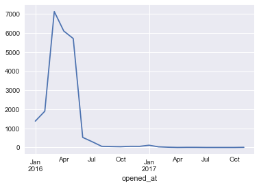

```python
monthly_resampled_opened_at_data.plot() # Visualize for better understanding
```

#### Notice:

- As we can observe that maximum incidents are recorded in end of 3rd month of 2016 (2016-03-31).
- And very less incidents are recorded the months of 2017 you can observe.

## Yearly

```python
yearly_resampled_opened_at_data  = m.number.resample('Y').count()
yearly_resampled_opened_at_data .sort_values(ascending = False)
```

```
opened_at
2016-12-31    23317
2017-12-31      181
Name: number, dtype: int64
```

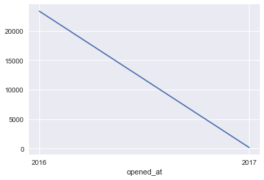

```python
yearly_resampled_opened_at_data .plot() # Visualize for better understanding
```

#### Notice:

- As we can observe number of incidents(complains) are reducing yearly which shows companie's progress that it is improving its product quality day by day.

## Daily

```python
daily_resampled_opened_at_data  = m.number.resample('D').count()
daily_resampled_opened_at_data.sort_values(ascending = False)
```

```
opened_at
2016-02-03    805
2016-03-03    786
2016-04-04    713
2016-02-05    672
2016-01-03    666
2016-04-05    598
2016-01-04    579
2016-05-05    569
2016-04-18    560
2016-03-16    555
2016-04-20    545
2016-03-21    540
2016-03-05    529
2016-03-14    528
2016-05-17    527
2016-05-18    524
2016-05-23    522
2016-05-16    519
2016-04-13    508
2016-03-17    502
2016-04-14    500
2016-03-15    479
2016-04-15    460
2016-03-28    460
2016-03-18    418
2016-04-19    387
2016-05-20    380
2016-03-24    378
2016-05-04    372
2016-05-13    372
             ...
2017-08-08      0
2017-08-07      0
2016-12-24      0
2017-08-06      0
2016-12-30      0
2016-12-31      0
2017-08-05      0
2017-08-04      0
```

[output cut: 8 more lines]

```
2017-01-11      0
2017-01-12      0
2017-08-03      0
2017-01-14      0
2017-01-15      0
2017-08-02      0
2017-01-20      0
2017-01-22      0
2017-08-01      0
2017-07-31      0
2017-01-29      0
2017-07-30      0
2017-07-29      0
2016-12-02      0
Name: number, Length: 669, dtype: int64
```

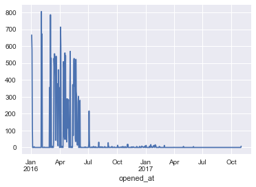

```python
daily_resampled_opened_at_data.plot() # Visualize for better understanding
```

#### Notice:

# Let's dive in more depth

```python
m.contact_type.isnull().sum() # no missing value
```

```
0
```

```python
p=m.contact_type.value_counts().sort_values(ascending = False)
p
```

```
Phone             23220
Self service        230
Email                36
IVR                   9
Direct opening        3
Name: contact_type, dtype: int64
```

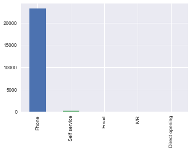

```python
p.plot.bar()  # visualize device_id for better understanding
```

#### Notice:

- As we can observe that maximum incidents were reported by **Phone**
- And minimum incidents were reported by **Direct opening**

```python
m.location.isnull().sum() #  missing value
```

```
35
```

```python
p=m.location.value_counts().sort_values(ascending = False)
p.head()
```

```
204    5051
161    3718
143    3376
93     2100
108    1909
Name: location, dtype: int64
```

#### Notice:

- As we can observe that location having identifier **204** is effected maximum times.

```python
df['location'] = df['location'].fillna('204')
```

- let's fill nan value with mode - location which occured maximum times in the original dataset.

```python
m.category.isnull().sum() # no missing value
```

```
36
```

```python
p=m.category.value_counts().sort_values(ascending = False)
p.head()
```

```
53.0    2765
26.0    2707
42.0    2568
46.0    2278
23.0    1718
Name: category, dtype: int64
```

```python
df['category'] = df['category'].fillna('53')
```

#### Notice:

- As we can observe that service category **53** is effected most.

```python
m.subcategory.isnull().sum() # no missing value
```

```
52
```

```python
p=m.subcategory.value_counts().sort_values(ascending = False)
p.head()
```

```
174.0    5913
223.0    2635
175.0    1547
164.0    1242
135.0     647
Name: subcategory, dtype: int64
```

```python
df['subcategory'] = df['subcategory'].fillna('174')
```

#### Notice:

- As we can observe that service subcategory **174** is effected most.

```python
p=m.impact.value_counts().sort_values(ascending = False)
p
```

```
2    22132
1      827
3      539
Name: impact, dtype: int64
```

- There are 827 incidents which have high impact.
- 22132 incidents are those which have medium and 539 incidents havelow impact

```python
m.groupby('impact').closed_at_opened_at.value_counts()
```

```
impact  closed_at_opened_at
1       6 days                 129
        5 days                  99
        153 days                62
        184 days                57
        182 days                31
        18 days                 25
        214 days                25
        11 days                 19
        13 days                 19
        245 days                17
        8 days                  16
        7 days                  15
        67 days                 15
        10 days                 14
```

[output cut: 48 more lines]

- you can notice 129 incidents having high impact are closed in just 6 days.

```python
p=m.urgency.value_counts().sort_values(ascending = False)
p.head()
```

```
2    22167
1      860
3      471
Name: urgency, dtype: int64
```

- There are 860 incidents which have high urgency informed by the user for the incident resolution.
- 22167 incidents are those which have medium and 471 incidents have less urgency.

```python
m.groupby('urgency').closed_at_opened_at.value_counts()
```

```
urgency  closed_at_opened_at
1        5 days                 184
         6 days                 117
         153 days                35
         7 days                  28
         182 days                26
         50 days                 22
         18 days                 21
         13 days                 20
         184 days                18
         8 days                  17
         26 days                 17
         245 days                17
         138 days                16
         20 days                 15
```

[output cut: 48 more lines]

- you can notice 184 incidents having high urgency are closed in just 5 days.

```python
p=m.priority.value_counts().sort_values(ascending = False)
p.head()
```

```
3    21717
2      779
4      550
1      452
Name: priority, dtype: int64
```

```python
m.groupby('priority').closed_at_opened_at.value_counts()
```

```
priority  closed_at_opened_at
1         6 days                 65
          5 days                 53
          153 days               24
          18 days                21
          182 days               20
          245 days               17
          13 days                16
          31 days                13
          11 days                12
          21 days                12
          184 days               12
          20 days                11
          138 days               10
          8 days                  8
```

[output cut: 48 more lines]

- priority: calculated by the system based on 'impact' and 'urgency';
- you can notice 65 incidents having high priority which are closed in just 6 day and 5 incidents are closed in the same day in which incident was recorded and so on.

```python
p=m.notify.value_counts().sort_values(ascending = False)
p.head()
```

```
Do Not Notify    23473
Send Email          25
Name: notify, dtype: int64
```

- notify shows whether notifications were generated for the incident;
- you can observe there are 23473 incidents which are Not Notify and 25 are those which are notified by Email

```python
m.resolved_by.value_counts().sort_values(ascending = False).head()
```

```
15     2376
11     1731
103    1297
177     940
62      677
Name: resolved_by, dtype: int64
```

- it means user having identifier 15 have resolved maximum incidents.

```python
df.columns
```

```
Index(['number', 'incident_state', 'active', 'reassignment_count',
       'reopen_count', 'sys_mod_count', 'made_sla', 'caller_id', 'opened_by',
       'opened_at', 'sys_created_by', 'sys_created_at', 'sys_updated_by',
       'sys_updated_at', 'contact_type', 'location', 'category', 'subcategory',
       'u_symptom', 'cmdb_ci', 'impact', 'urgency', 'priority',
       'assignment_group', 'assigned_to', 'knowledge',
       'u_priority_confirmation', 'notify', 'problem_id', 'rfc', 'vendor',
       'caused_by', 'closed_code', 'resolved_by', 'resolved_at', 'closed_at',
       'closed_at_opened_at'],
      dtype='object')
```

# Feature Selection

I drop unnecessary columns/features and keep only the useful ones for prediction task.

```python
selected_df= df.copy()
```

```python
features_drop = [ 'number','active',  'made_sla', 'caller_id', 'opened_by','opened_at',
       'sys_created_by', 'sys_created_at', 'sys_updated_by', 'sys_updated_at', 'u_symptom',
          'cmdb_ci', 'impact', 'urgency', 'assignment_group',
       'assigned_to', 'knowledge', 'u_priority_confirmation', 'notify',
       'problem_id', 'rfc', 'vendor', 'caused_by', 'closed_code',
       'resolved_by', 'resolved_at', 'closed_at', ]

selected_df = selected_df.drop(features_drop, axis=1)
```

# Covert all features into numeric

```python
selected_df['closed_at_opened_at'] = selected_df['closed_at_opened_at'].apply(lambda x: str(x).split(' ')[0] if x != np.nan else np.nan)
```

```python
# Convert the data type of column
selected_df = selected_df.astype({'category': 'int64', 'subcategory': 'int64', 'closed_at_opened_at': 'int64','location': 'int64'})
```

```python
selected_df.info()
```

```
<class 'pandas.core.frame.DataFrame'>
Int64Index: 91228 entries, 0 to 141711
Data columns (total 10 columns):
incident_state         91228 non-null object
reassignment_count     91228 non-null int64
reopen_count           91228 non-null int64
sys_mod_count          91228 non-null int64
contact_type           91228 non-null object
location               91228 non-null int64
category               91228 non-null int64
subcategory            91228 non-null int64
priority               91228 non-null int64
closed_at_opened_at    91228 non-null int64
dtypes: int64(8), object(2)
memory usage: 7.7+ MB
```

# Label Encoding

```python
labelEncoder_incident_state = LabelEncoder()
labelEncoder_incident_state.fit(selected_df.incident_state)
selected_df['incident_state']=labelEncoder_incident_state.transform(selected_df.incident_state)
```

```python
labelEncoder_contact_type = LabelEncoder()
labelEncoder_contact_type.fit(selected_df.contact_type)
selected_df['contact_type']=labelEncoder_contact_type.transform(selected_df.contact_type)
```

```python
selected_df.head()
```

|  | incident_state | reassignment_count | reopen_count | sys_mod_count | contact_type | location | category | subcategory | priority | closed_at_opened_at |
| --- | --- | --- | --- | --- | --- | --- | --- | --- | --- | --- |
| 0 | 6 | 0 | 0 | 0 | 3 | 143 | 55 | 170 | 3 | 64 |
| 1 | 7 | 0 | 0 | 2 | 3 | 143 | 55 | 170 | 3 | 64 |
| 2 | 7 | 0 | 0 | 3 | 3 | 143 | 55 | 170 | 3 | 64 |
| 3 | 5 | 0 | 0 | 4 | 3 | 143 | 55 | 170 | 3 | 64 |
| 4 | 6 | 0 | 0 | 0 | 3 | 165 | 40 | 215 | 3 | 95 |

```python
selected_df = selected_df.head(200)
```

# Define training and testing set

```python
from sklearn.model_selection import GridSearchCV

X= selected_df.drop('closed_at_opened_at', axis=1)
y= selected_df['closed_at_opened_at']
```

```python
# split data into training and validation data
train_X, val_X, train_y, val_y = train_test_split(X, y, random_state = 0)
```

# Preparing the Models.

```python
def create_models(models):
    all_models = []

    for model in models:
        if model == "LogisticRegressionCV":
            all_models.append(('LogisticRegressionCV', LogisticRegressionCV()))
        elif model == "KNeighborsClassifier":
            all_models.append(('KNeighborsClassifier', KNeighborsClassifier(n_neighbors=3)))

        elif model == "RandomForestRegressor":
            all_models.append(('RandomForestRegressor', RandomForestRegressor()))
         #   pickle.dump(model, open("RandomForestClassifier.pkl", "wb"))
        elif model == "DecisionTreeClassifier":
            all_models.append(('DecisionTreeClassifier', DecisionTreeClassifier() ))
        elif model == "GradientBoostingClassifier":
            all_models.append(('GradientBoostingClassifier', GradientBoostingClassifier()))
    return all_models
```

## Change Hyper Parameters

```python
def ChangeHyperParameters(models):
    all_models = []

    for model in models:
        if model == "LogisticRegressionCV":
            all_models.append(('LogisticRegressionCV ', LogisticRegressionCV(cv=20,  max_iter=100,)))
        elif model == "KNeighborsClassifier":
            all_models.append(('KNeighborsClassifier', KNeighborsClassifier(n_neighbors=3,leaf_size=50,p=10)))
        elif model == "RandomForestRegressor":
            all_models.append(('RandomForestRegressor', RandomForestRegressor(n_estimators = 100,oob_score = True ,random_state =1)))
         #   pickle.dump(model, open("RandomForestRegressor.pkl", "wb"))
        elif model == "DecisionTreeClassifier":
            all_models.append(('DecisionTreeClassifier', DecisionTreeClassifier(max_leaf_nodes=50)))
        elif model == "GradientBoostingClassifier":
            all_models.append(('GradientBoostingClassifier', GradientBoostingClassifier(learning_rate=0.5, n_estimators=50,max_depth=2,
                                                                                        min_samples_split=2,
                                                                                        max_features='sqrt', random_state=5)))
    return all_models
```

# Training the Models.

```python
def fit_models(all_models, train_X, val_X, train_y, val_y):

    t = PrettyTable(['Model','error'])
    print('')
    # Iterating all models one by one
    for name, model in all_models:
        print('Fitting:',name)
        trained_model = model.fit(train_X,train_y.values.ravel())
        prediction = trained_model.predict(val_X)
        error = mean_absolute_error(val_y, prediction)

        t.add_row([name, round(error,3)])
    print('\n\nDetailed Performance Of All Models.')
    print("=======================================")
    print(t)
```

# Main

```python
models = ["LogisticRegressionCV","KNeighborsClassifier","SVC","RandomForestClassifier","DecisionTreeClassifier","GradientBoostingClassifier"]

# Create Models
all_models = create_models(models)

# Model Evaluation
fit_models(all_models, train_X, val_X, train_y, val_y)
```

```
Fitting: LogisticRegressionCV
Fitting: KNeighborsClassifier
Fitting: DecisionTreeClassifier
Fitting: GradientBoostingClassifier


Detailed Performance Of All Models.
=======================================
+----------------------------+-------+
|           Model            | error |
+----------------------------+-------+
|    LogisticRegressionCV    | 22.06 |
|    KNeighborsClassifier    |  1.7  |
|   DecisionTreeClassifier   |  0.48 |
| GradientBoostingClassifier |  0.48 |
+----------------------------+-------+
```

```python
# CHANGE HYPER PARAMETER

# Create Models
all_models = ChangeHyperParameters(models)

# Model Evaluation
fit_models(all_models, train_X, val_X, train_y, val_y)
```

```
Fitting: LogisticRegressionCV
Fitting: KNeighborsClassifier
Fitting: DecisionTreeClassifier
Fitting: GradientBoostingClassifier


Detailed Performance Of All Models.
=======================================
+----------------------------+-------+
|           Model            | error |
+----------------------------+-------+
|   LogisticRegressionCV     | 21.46 |
|    KNeighborsClassifier    |  1.7  |
|   DecisionTreeClassifier   |  0.48 |
| GradientBoostingClassifier |  0.48 |
+----------------------------+-------+
```

As you can see in above comparison last two classifiers have minimum error. I am going to select DecisionTreeClassifier as best model.

```python
BestModel=DecisionTreeClassifier()
```

# Train Best Model on All Data

```python
x_alldata= selected_df.drop('closed_at_opened_at', axis=1)
y_alldata= selected_df['closed_at_opened_at']
```

```python
BestModel.fit(x_alldata, y_alldata)
```

```
DecisionTreeClassifier(class_weight=None, criterion='gini', max_depth=None,
            max_features=None, max_leaf_nodes=None,
            min_impurity_decrease=0.0, min_impurity_split=None,
            min_samples_leaf=1, min_samples_split=2,
            min_weight_fraction_leaf=0.0, presort=False, random_state=None,
            splitter='best')
```

# Save the Trained Model as Pickle File

```python
file = open('BestModel.pkl','wb')
pickle.dump(BestModel,file)
file.close()
```

# Load the Trained Model

```python
infile = open('BestModel.pkl','rb')
bestmodel = pickle.load(infile)
infile.close()
```

# Take Input from User

```python
selected_df.head()
```

|  | incident_state | reassignment_count | reopen_count | sys_mod_count | contact_type | location | category | subcategory | priority | closed_at_opened_at |
| --- | --- | --- | --- | --- | --- | --- | --- | --- | --- | --- |
| 0 | 6 | 0 | 0 | 0 | 3 | 143 | 55 | 170 | 3 | 64 |
| 1 | 7 | 0 | 0 | 2 | 3 | 143 | 55 | 170 | 3 | 64 |
| 2 | 7 | 0 | 0 | 3 | 3 | 143 | 55 | 170 | 3 | 64 |
| 3 | 5 | 0 | 0 | 4 | 3 | 143 | 55 | 170 | 3 | 64 |
| 4 | 6 | 0 | 0 | 0 | 3 | 165 | 40 | 215 | 3 | 95 |

```python
incident_state=input("Please Enter incident_state here: ")
reassignment_count=input("Please Enter your reassignment_count: ")
reopen_count  =input("Please Enter reopen_count: ")
sys_mod_count = input("Please Enter sys_mod_count: ")
contact_type = input("Please Enter contact_type: ")
location  =input("Please Enter location: ")
category  =input("Please Enter category: ")
subcategory  =input("Please Enter subcategory: ")
priority  =input("Please Enter priority: ")
```

```
Please Enter incident_state here: New
Please Enter your reassignment_count: 2
Please Enter reopen_count: 2
Please Enter sys_mod_count: 2
Please Enter contact_type: Phone
Please Enter location: 143
Please Enter category: 55
Please Enter subcategory: 170
Please Enter priority: 3
```

```python
 dictt={'incident_state':[incident_state],'reassignment_count':[reassignment_count], 'reopen_count': [reopen_count],'sys_mod_count':[sys_mod_count ],'contact_type':[contact_type],'location':[location],'category':[category]
       ,'subcategory':[subcategory],'priority':[priority]}
```

# Convert User Input into Feature Vector

```python
input1 = pd.DataFrame(dictt)
print("User Input in Actual Dataframe form : ")
input1
```

```
User Input in Actual Dataframe form :
```

|  | incident_state | reassignment_count | reopen_count | sys_mod_count | contact_type | location | category | subcategory | priority |
| --- | --- | --- | --- | --- | --- | --- | --- | --- | --- |
| 0 | New | 2 | 2 | 2 | Phone | 143 | 55 | 170 | 3 |

```python
labelEncoder_incident_state.transform(input1.incident_state)
labelEncoder_contact_type.transform(input1.contact_type)
```

```
array([3], dtype=int64)
```

```python
input1['incident_state'] =labelEncoder_incident_state.transform(input1.incident_state)
input1['contact_type'] =labelEncoder_contact_type.transform(input1.contact_type)
```

```python
print("User Input in Encoded Dataframe form : ")
input1
```

```
User Input in Encoded Dataframe form :
```

|  | incident_state | reassignment_count | reopen_count | sys_mod_count | contact_type | location | category | subcategory | priority |
| --- | --- | --- | --- | --- | --- | --- | --- | --- | --- |
| 0 | 6 | 2 | 2 | 2 | 3 | 143 | 55 | 170 | 3 |

# Apply Trained Model on Feature Vector of Unseen Data

```python
y_predict = bestmodel.predict(input1)
```

# Output Prediction to User

```python
print("Prediction : {} days are required to close this incident ".format((y_predict)))
```

```
Prediction : [64] days are required to close this incident
```